# Colorado & Texas Beer

Linda Eliasen

March 11, 2019

*Personal SMU Repository: https://github.com/laelias7/SMU-MSDS.git*

### Background

Brewmeisters in Colorado and Texas have teamed up to analyze the relationship between ABV and IBU in each of their states.

Their three main questions of interest are:  
1) Is there a significant linear relationship between ABV (response) and IBU (explanatory)  
2) Is this relationship different between beers in Colorado and Texas  
3) Is there a significant quadratic component in this relationship for either Colorado or Texas or both?

### Clean and prepare the data

Read in data files and merge based on brewery id

```r
brew<- read.csv("breweries.csv" , header=TRUE, stringsAsFactors=FALSE)
colnames(brew)<- c('Brewery_id', 'Name', 'City', 'State')

beer <- read.csv("beers.csv" , header=TRUE, stringsAsFactors=FALSE)

brew<-merge(brew,beer, by="Brewery_id",all.x = TRUE)
colnames(brew)<- c('Brewery_id', 'Brewery', 'City', 'State', 'Beer', 'Beer_ID', 'ABV', 'IBU', 'Style', 'Ounces')
brew$IBU <- as.numeric(brew$IBU)
```

Format and create new file with Colorado and Texas data. Show the first few rows of the data.

```r
#need to remove extra spaces from state abreviation
brew %<>% mutate(State = gsub(' ', '', State))

#Pullling CO and TX from the data
co<-brew[grep("CO", brew$State),]
tx<-brew[grep("TX", brew$State),]

#Final data set with CO and TX; removing NAs and reordering
beerCOTX<-rbind(co,tx)
beerCOTX<-beerCOTX[-which(is.na(beerCOTX$IBU)),]
beerCOTX = beerCOTX[order(beerCOTX$IBU),]
#check file
kable(head(beerCOTX,6))%>%
  kable_styling(bootstrap_options = "striped", "condensed")
```

|  | Brewery_id | Brewery | City | State | Beer | Beer_ID | ABV | IBU | Style | Ounces |
| --- | --- | --- | --- | --- | --- | --- | --- | --- | --- | --- |
| 462 | 67 | Freetail Brewing Company | San Antonio | TX | Yo Soy Un Berliner | 2520 | 0.044 | 5 | Berliner Weissbier | 12 |
| 754 | 129 | Real Ale Brewing Company | Blanco | TX | 18th Anniversary Gose | 2370 | 0.044 | 5 | Gose | 12 |
| 1947 | 392 | Breckenridge Brewery | Denver | CO | Agave Wheat | 1522 | 0.042 | 9 | American Pale Wheat Ale | 12 |
| 280 | 38 | Avery Brewing Company | Boulder | CO | White Rascal | 108 | 0.056 | 10 | Witbier | 12 |
| 458 | 67 | Freetail Brewing Company | San Antonio | TX | Rye Wit | 2522 | 0.042 | 10 | Witbier | 12 |
| 2257 | 497 | Dry Dock Brewing Company | Aurora | CO | Dry Dock Hefeweizen | 872 | 0.043 | 12 | Hefeweizen | 12 |

### Create initial plots of the data

Plot ABV v. IBU for both Colorado and Texas.

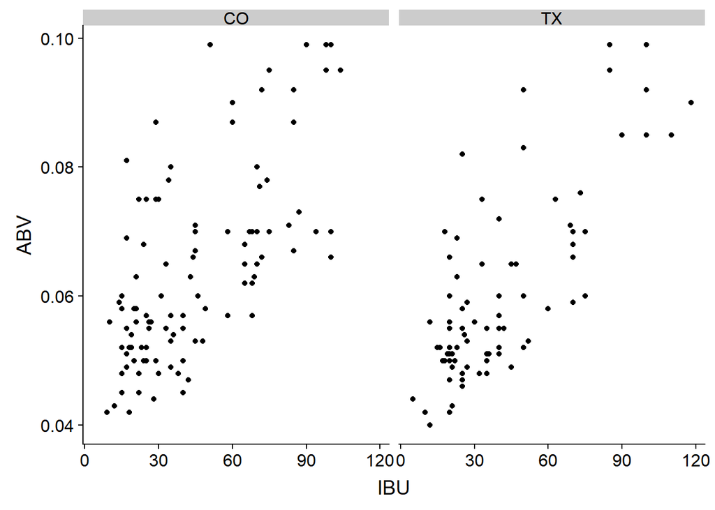

```r
p <- ggplot(data = beerCOTX, aes(x = IBU, y = ABV)) + geom_point()
p + facet_wrap(~State)
```

### Model the data

For each state, fit a simple linear regression model to assess the relationship between ABV and IBU. Use the regular plot function in base R to create a scatter plot with the regression line superimposed on the plot.

#### Colorado

The data exhibits a positive linear relationship, as the IBU level of beer increases, so does the alcohol by volume. Based on the regression results, we see that IBU accounts for roughly 44% of the variance in ABV levels.

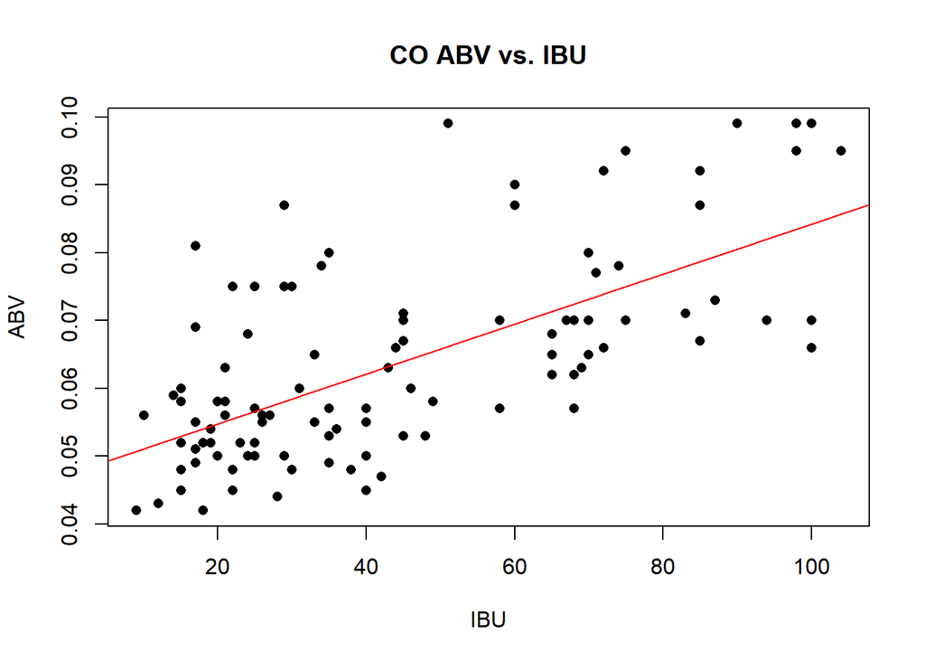

```r
sco<- filter(beerCOTX, State == "CO")

fit = lm(ABV~IBU,data = sco)
fit.res = resid(fit)

  # Scatterplot
plot(sco$IBU, sco$ABV, main="CO ABV vs. IBU",
   xlab="IBU", ylab="ABV", pch=16)
# Add fit lines
abline(lm(sco$ABV~sco$IBU), col="red")
```

```r
summary(fit)
```

```
##
## Call:
## lm(formula = ABV ~ IBU, data = sco)
##
## Residuals:
##       Min        1Q    Median        3Q       Max
## -0.018158 -0.007266 -0.003293  0.006453  0.032853
##
## Coefficients:
##              Estimate Std. Error t value Pr(>|t|)
## (Intercept) 4.740e-02  1.856e-03   25.54   <2e-16 ***
## IBU         3.676e-04  3.432e-05   10.71   <2e-16 ***
## ---
## Signif. codes:  0 '***' 0.001 '**' 0.01 '*' 0.05 '.' 0.1 ' ' 1
##
## Residual standard error: 0.01077 on 144 degrees of freedom
## Multiple R-squared:  0.4433, Adjusted R-squared:  0.4395
## F-statistic: 114.7 on 1 and 144 DF,  p-value: < 2.2e-16
```

#### Texas

Although there is some clustering towards the lower end of the graph, We see a positive linear relationship. As the IBU increases, so does the alcohol by volume. Based on the regression results, we see that IBU accounts for 59% of the variance in ABV levels.

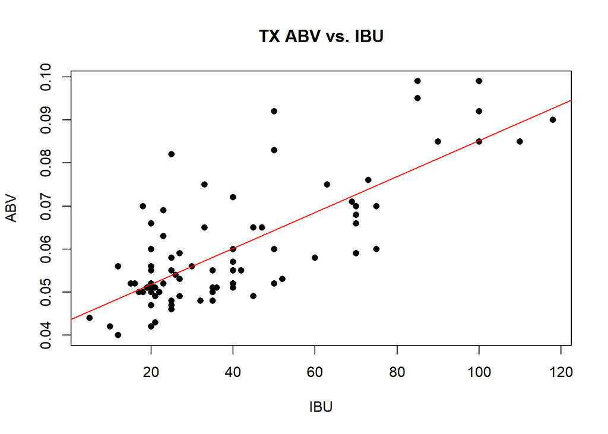

```r
stx<- filter(beerCOTX, State == "TX")

fit2 = lm(ABV~IBU,data = stx)
fit.res2 = resid(fit2)

  # Scatterplot
plot(stx$IBU, stx$ABV, main="TX ABV vs. IBU",
   xlab="IBU", ylab="ABV", pch=16)
# Add fit lines
abline(lm(stx$ABV~stx$IBU), col="red")
```

```r
summary(fit2)
```

```
##
## Call:
## lm(formula = ABV ~ IBU, data = stx)
##
## Residuals:
##       Min        1Q    Median        3Q       Max
## -0.014764 -0.005738 -0.001560  0.003182  0.028096
##
## Coefficients:
##              Estimate Std. Error t value Pr(>|t|)
## (Intercept) 4.347e-02  1.772e-03   24.54   <2e-16 ***
## IBU         4.172e-04  3.683e-05   11.33   <2e-16 ***
## ---
## Signif. codes:  0 '***' 0.001 '**' 0.01 '*' 0.05 '.' 0.1 ' ' 1
##
## Residual standard error: 0.009078 on 87 degrees of freedom
## Multiple R-squared:  0.596,  Adjusted R-squared:  0.5914
## F-statistic: 128.3 on 1 and 87 DF,  p-value: < 2.2e-16
```

### Address the assumptions of the regression model

#### Colorado

The relationship between the two variables appears to be linear. Generally, as IBU increases so does ABV.  
In the residuals versus predicted plot, the residuals are randomly scattered around the center line of zero, with no obvious pattern. There also appears to be equal variance of the errors. Note that there are three points that may be evidence of outliers, but they don’t seem to have a noticeable impact.  
The histogram of residuals and qq plot are approximately normally distributed. Note that there is slight curvature in the qqplot, but it does not create a significant departure from normality.

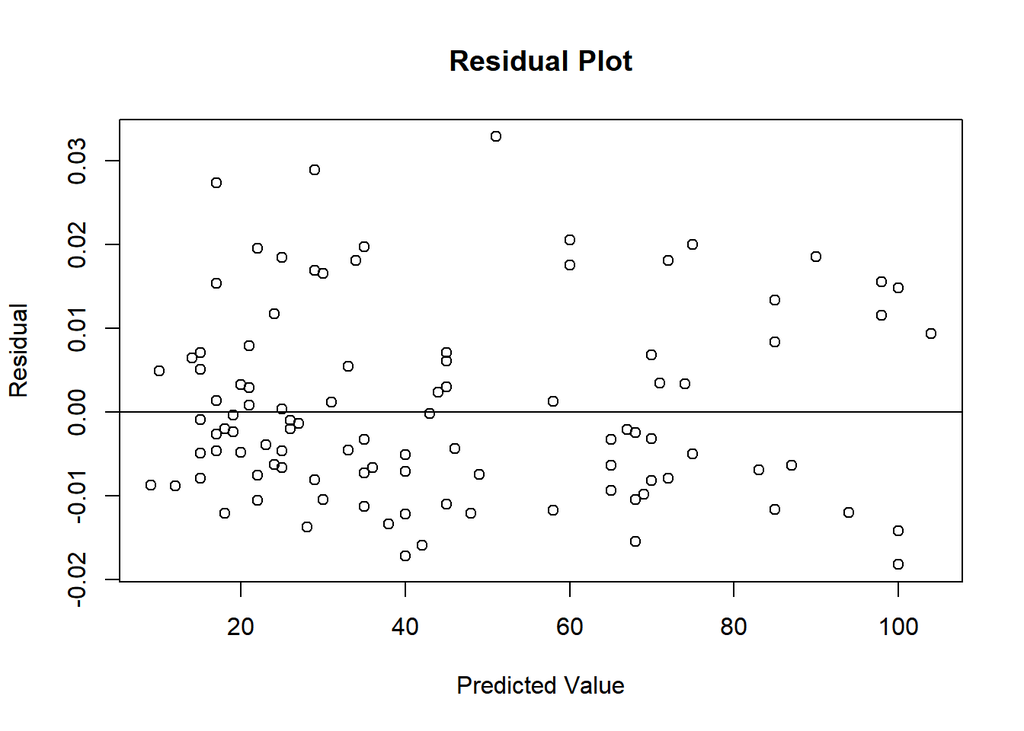

```r
#residual pattern only
resfit<-resid(fit)
plot(sco$IBU, resfit, ylab = "Residual", xlab="Predicted Value", main = "Residual Plot")
abline(0, 0)
```

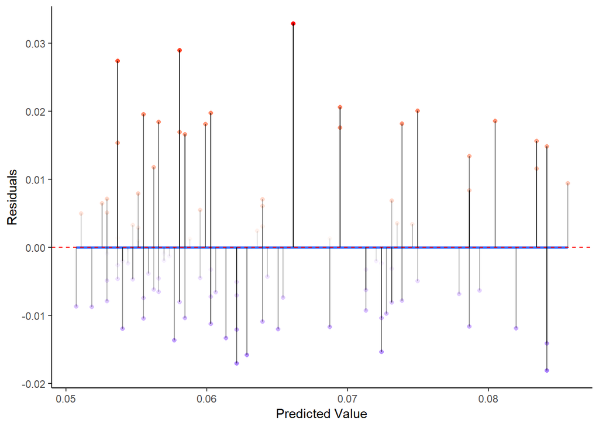

```r
 #residual graph for equal variance
 res<-ggplot(fit, aes(.fitted, .resid))+
  geom_point(aes(color = .resid)) +
  scale_color_gradient2(low = "blue",
                        mid = "white",
                        high = "red") +
  guides(color = FALSE)
res<-res+
  stat_smooth(method="lm",se=F)+
  geom_hline(yintercept=0,
             col="red",
             linetype="dashed")
res<-res+
  xlab("Predicted Value")+
  ylab("Residuals")
res<-res+theme_classic()
res+geom_segment(aes(y=0,x=.fitted,xend=.fitted, yend=.resid,alpha = 2*abs(.resid)))+guides(alpha=FALSE)
```

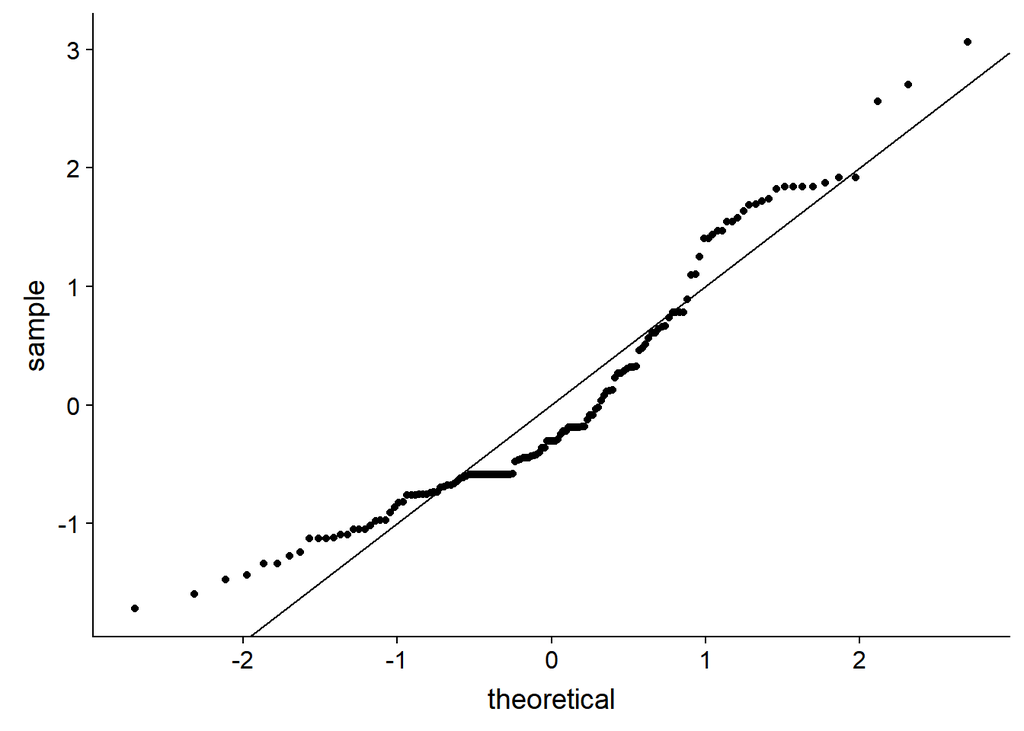

```r
 #QQPlot for standardized residuals
 ggplot(fit)+
   stat_qq(aes(sample=.stdresid))+
   geom_abline()
```

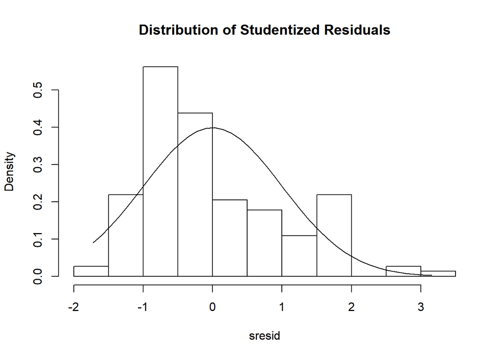

```r
#Histogram
 sresid <- studres(fit)
hist(sresid, freq=FALSE,
   main="Distribution of Studentized Residuals")
xfit<-seq(min(sresid),max(sresid),length=40)
yfit<-dnorm(xfit)
lines(xfit, yfit)
```

#### Texas

The relationship between the two variables appears to be linear. Generally, as IBU increases so does ABV. However, we do see slight clustering at the lower levels.  
In the residuals versus predicted plot, the residuals are randomly scattered around the center line of zero, with no obvious pattern. There also appears to be equal variance of the errors. Again, we have to be mindful of the slight clustering and a couple of potential outliers.  
The histogram of residuals and qq plot are approximately normally distributed, although we do note that there is mild right skewness.

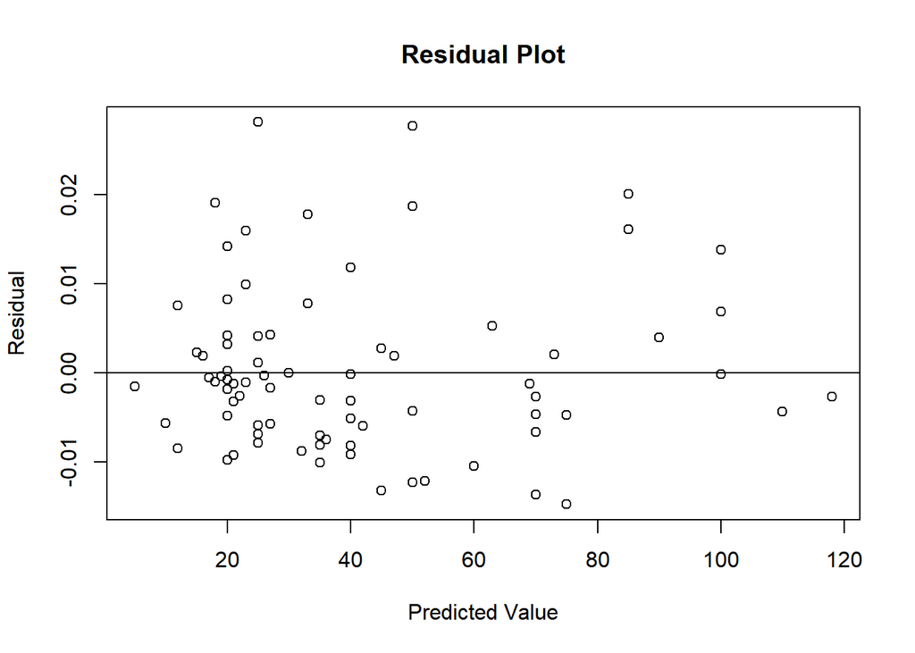

```r
#residual pattern only
resfit2<-resid(fit2)
plot(stx$IBU, resfit2, ylab = "Residual", xlab="Predicted Value", main = "Residual Plot")
abline(0, 0)
```

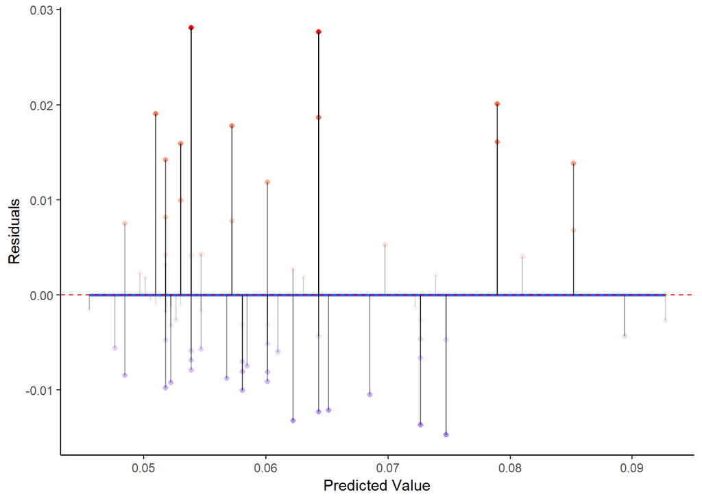

```r
 #residual graph for equal variance
 res2<-ggplot(fit2, aes(.fitted, .resid))+
  geom_point(aes(color = .resid)) +
  scale_color_gradient2(low = "blue",
                        mid = "white",
                        high = "red") +
  guides(color = FALSE)
res2<-res2+
  stat_smooth(method="lm",se=F)+
  geom_hline(yintercept=0,
             col="red",
             linetype="dashed")
res2<-res2+
  xlab("Predicted Value")+
  ylab("Residuals")
res2<-res2+theme_classic()
res2+geom_segment(aes(y=0,x=.fitted,xend=.fitted, yend=.resid,alpha = 2*abs(.resid)))+guides(alpha=FALSE)
```

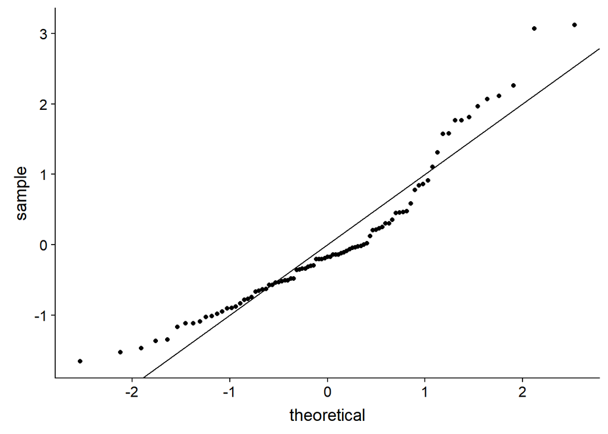

```r
 #QQPlot for standardized residuals
 ggplot(fit2)+
   stat_qq(aes(sample=.stdresid))+
   geom_abline()
```

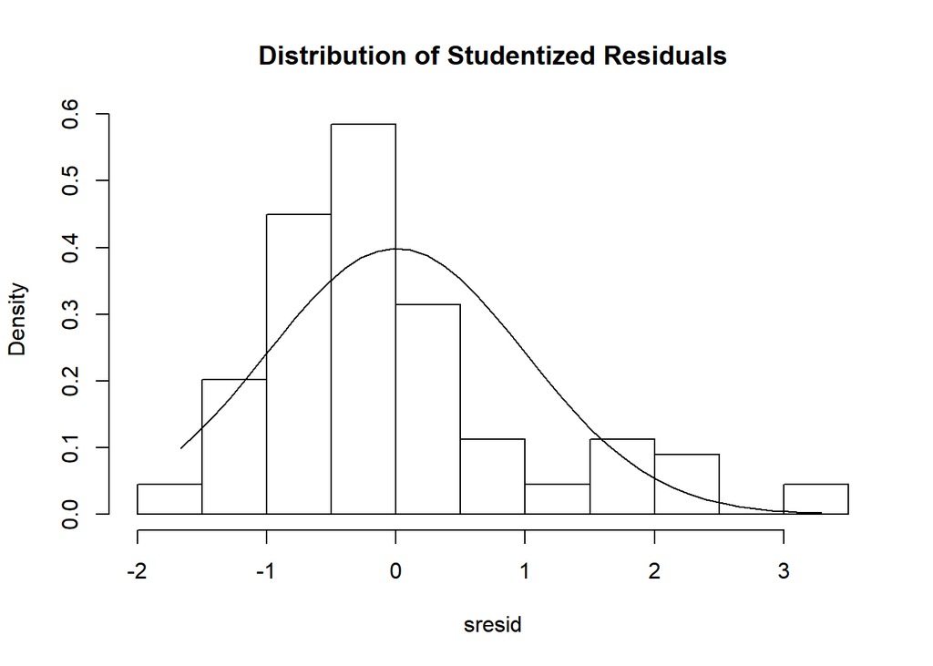

```r
#Histogram
 sresid <- studres(fit2)
hist(sresid, freq=FALSE,
   main="Distribution of Studentized Residuals")
xfit2<-seq(min(sresid),max(sresid),length=40)
yfit2<-dnorm(xfit2)
lines(xfit2, yfit2)
```

### Gain inference from the model

#### Interpret the slope of the regression model.

#### Colorado

Predicted ABV =0.0474013 + 0.0003676(IBU). For every one unit increase in IBU, ABV will increase by 0.037%.  
We are 95% confident that for every one unit increase in IBU, the ABV increase will be between 0.030% and 0.044%

```r
  fit.table <- xtable(fit)
  kable(fit.table, caption = "CO Model 1:  ABV = B0+B1(IBU)")%>%
kable_styling(bootstrap_options = "striped", "condensed")
```

CO Model 1: ABV = B0+B1(IBU)

|  | Estimate | Std. Error | t value | Pr(>\|t\|) |
| --- | --- | --- | --- | --- |
| (Intercept) | 0.0474013 | 0.0018561 | 25.53790 | 0 |
| IBU | 0.0003676 | 0.0000343 | 10.70893 | 0 |

```r
 #Conf Interval alpha = .05
cin.table<-xtable(confint(fit))
kable(cin.table, caption = "95% Confidence Interval")%>%
kable_styling(bootstrap_options = "striped", "condensed")
```

95% Confidence Interval

|  | 2.5 % | 97.5 % |
| --- | --- | --- |
| (Intercept) | 0.0437325 | 0.0510700 |
| IBU | 0.0002997 | 0.0004354 |

#### Texas

Predicted ABV =0.0434737 + 0.0004172(IBU). For every one unit increase in IBU, ABV will increase by 0.042%.  
We are 95% confident that for every one unit increase in IBU, the ABV increase will be between 0.034% and 0.049%

```r
  fit.table2 <- xtable(fit2)
  kable(fit.table2, caption = "Model 1:  ABV = B0+B1(IBU)")%>%
kable_styling(bootstrap_options = "striped", "condensed")
```

Model 1: ABV = B0+B1(IBU)

|  | Estimate | Std. Error | t value | Pr(>\|t\|) |
| --- | --- | --- | --- | --- |
| (Intercept) | 0.0434737 | 0.0017716 | 24.53897 | 0 |
| IBU | 0.0004172 | 0.0000368 | 11.32900 | 0 |

```r
  #Conf Interval alpha = .05
cin.table2<-xtable(confint(fit2))
kable(cin.table2, caption = "95% Confidence Interval")%>%
kable_styling(bootstrap_options = "striped", "condensed")
```

95% Confidence Interval

|  | 2.5 % | 97.5 % |
| --- | --- | --- |
| (Intercept) | 0.0399524 | 0.0469949 |
| IBU | 0.0003440 | 0.0004904 |

### Compare two competing models: External Cross Validation

Using the beerCOTX dataframe, add a column to the data that is the square of the IBU column. Call it IBU2. Print the head of the dataframe with the new column.

```r
beerCOTX<-beerCOTX%>% mutate(`IBU2`= IBU^2)

kable(head(beerCOTX,6))%>%
  kable_styling(bootstrap_options = "striped", "condensed")
```

| Brewery_id | Brewery | City | State | Beer | Beer_ID | ABV | IBU | Style | Ounces | IBU2 |
| --- | --- | --- | --- | --- | --- | --- | --- | --- | --- | --- |
| 67 | Freetail Brewing Company | San Antonio | TX | Yo Soy Un Berliner | 2520 | 0.044 | 5 | Berliner Weissbier | 12 | 25 |
| 129 | Real Ale Brewing Company | Blanco | TX | 18th Anniversary Gose | 2370 | 0.044 | 5 | Gose | 12 | 25 |
| 392 | Breckenridge Brewery | Denver | CO | Agave Wheat | 1522 | 0.042 | 9 | American Pale Wheat Ale | 12 | 81 |
| 38 | Avery Brewing Company | Boulder | CO | White Rascal | 108 | 0.056 | 10 | Witbier | 12 | 100 |
| 67 | Freetail Brewing Company | San Antonio | TX | Rye Wit | 2522 | 0.042 | 10 | Witbier | 12 | 100 |
| 497 | Dry Dock Brewing Company | Aurora | CO | Dry Dock Hefeweizen | 872 | 0.043 | 12 | Hefeweizen | 12 | 144 |

For each state, create a training and test set from the data (60%/40% split respectively).  
Print a summary of each new data frame. there should be four: TrainingCO, TestCO, TrainingTX, TestTX.

```r
sco2<- filter(beerCOTX, State == "CO")

set.seed(8)
trainIndex<-createDataPartition(sco2$ABV,p=0.6,list=FALSE,times=1)
TrainingCO<-sco2[trainIndex,]
TestCO<-sco2[-trainIndex,]

stx2<- filter(beerCOTX, State == "TX")

set.seed(8)
trainIndex2<-createDataPartition(stx2$ABV,p=0.6,list=FALSE,times=1)
TrainingTX<-stx2[trainIndex2,]
TestTX<-stx2[-trainIndex2,]
```

Summary: TrainingCO

```r
summary(TrainingCO)
```

```
##    Brewery_id      Brewery              City              State
##  Min.   :  7.0   Length:89          Length:89          Length:89
##  1st Qu.:111.0   Class :character   Class :character   Class :character
##  Median :167.0   Mode  :character   Mode  :character   Mode  :character
##  Mean   :251.2
##  3rd Qu.:406.0
##  Max.   :524.0
##      Beer              Beer_ID            ABV               IBU
##  Length:89          Min.   :   1.0   Min.   :0.04200   Min.   :  9.00
##  Class :character   1st Qu.: 397.0   1st Qu.:0.05200   1st Qu.: 25.00
##  Mode  :character   Median : 786.0   Median :0.06500   Median : 45.00
##                     Mean   : 957.1   Mean   :0.06452   Mean   : 49.12
##                     3rd Qu.:1452.0   3rd Qu.:0.07100   3rd Qu.: 68.00
##                     Max.   :2644.0   Max.   :0.09900   Max.   :100.00
##     Style               Ounces           IBU2
##  Length:89          Min.   :12.00   Min.   :   81
##  Class :character   1st Qu.:12.00   1st Qu.:  625
##  Mode  :character   Median :12.00   Median : 2025
##                     Mean   :12.93   Mean   : 3072
##                     3rd Qu.:12.00   3rd Qu.: 4624
##                     Max.   :19.20   Max.   :10000
```

Summary: TestCO

```r
summary(TestCO)
```

```
##    Brewery_id      Brewery              City              State
##  Min.   : 38.0   Length:57          Length:57          Length:57
##  1st Qu.:105.0   Class :character   Class :character   Class :character
##  Median :167.0   Mode  :character   Mode  :character   Mode  :character
##  Mean   :241.5
##  3rd Qu.:421.0
##  Max.   :524.0
##      Beer              Beer_ID          ABV               IBU
##  Length:57          Min.   :   7   Min.   :0.04300   Min.   : 10.00
##  Class :character   1st Qu.: 726   1st Qu.:0.05300   1st Qu.: 24.00
##  Mode  :character   Median :1167   Median :0.06500   Median : 35.00
##                     Mean   :1270   Mean   :0.06533   Mean   : 44.79
##                     3rd Qu.:1932   3rd Qu.:0.07000   3rd Qu.: 65.00
##                     Max.   :2563   Max.   :0.09900   Max.   :104.00
##     Style               Ounces           IBU2
##  Length:57          Min.   :12.00   Min.   :  100
##  Class :character   1st Qu.:12.00   1st Qu.:  576
##  Mode  :character   Median :12.00   Median : 1225
##                     Mean   :13.49   Mean   : 2693
##                     3rd Qu.:16.00   3rd Qu.: 4225
##                     Max.   :19.20   Max.   :10816
```

Summary: TrainingTX

```r
summary(TrainingTX)
```

```
##    Brewery_id      Brewery              City              State
##  Min.   : 30.0   Length:55          Length:55          Length:55
##  1st Qu.:122.5   Class :character   Class :character   Class :character
##  Median :129.0   Mode  :character   Mode  :character   Mode  :character
##  Mean   :161.5
##  3rd Qu.:211.0
##  Max.   :427.0
##      Beer              Beer_ID          ABV               IBU
##  Length:55          Min.   :  45   Min.   :0.04200   Min.   :  5.00
##  Class :character   1st Qu.:1208   1st Qu.:0.05050   1st Qu.: 21.00
##  Mode  :character   Median :2043   Median :0.05500   Median : 27.00
##                     Mean   :1721   Mean   :0.06069   Mean   : 38.89
##                     3rd Qu.:2238   3rd Qu.:0.06850   3rd Qu.: 48.50
##                     Max.   :2527   Max.   :0.09900   Max.   :118.00
##     Style               Ounces           IBU2
##  Length:55          Min.   :12.00   Min.   :   25
##  Class :character   1st Qu.:12.00   1st Qu.:  441
##  Mode  :character   Median :12.00   Median :  729
##                     Mean   :12.87   Mean   : 2129
##                     3rd Qu.:12.00   3rd Qu.: 2354
##                     Max.   :16.00   Max.   :13924
```

Summary: TestTX

```r
summary(TestTX)
```

```
##    Brewery_id      Brewery              City              State
##  Min.   : 30.0   Length:34          Length:34          Length:34
##  1st Qu.:119.0   Class :character   Class :character   Class :character
##  Median :128.5   Mode  :character   Mode  :character   Mode  :character
##  Mean   :156.6
##  3rd Qu.:215.8
##  Max.   :427.0
##      Beer              Beer_ID          ABV               IBU
##  Length:34          Min.   :  44   Min.   :0.04000   Min.   :  5.00
##  Class :character   1st Qu.:1235   1st Qu.:0.05025   1st Qu.: 20.25
##  Mode  :character   Median :1938   Median :0.05500   Median : 35.00
##                     Mean   :1754   Mean   :0.05974   Mean   : 42.82
##                     3rd Qu.:2189   3rd Qu.:0.06600   3rd Qu.: 50.00
##                     Max.   :2600   Max.   :0.09200   Max.   :110.00
##     Style               Ounces           IBU2
##  Length:34          Min.   :12.00   Min.   :   25.0
##  Class :character   1st Qu.:12.00   1st Qu.:  410.2
##  Mode  :character   Median :12.00   Median : 1225.0
##                     Mean   :12.71   Mean   : 2614.2
##                     3rd Qu.:12.00   3rd Qu.: 2500.0
##                     Max.   :16.00   Max.   :12100.0
```

### Brewmeisters are curious if the relationship between ABV and IBU is purely linear or if there is evidence of a quadratic component as well. To test this we would like to compare two models:

Model 1: ABV = B0+B1(IBU)  
Model 2: ABV = B0+B1(IBU)+B2(IBU)^2

### Colorado

```r
#Model1 - Colorado Training Set
fitTrainCO = lm(ABV~IBU,data = TrainingCO)
predstrainCO = predict(fitTrainCO)
predstestCO = predict(fitTrainCO, newdata = TestCO)

#MSE Model 1 - Colorado Training Set
MSEholderTrainingCO = sum((predstrainCO - TrainingCO$ABV)^2)/(length(TrainingCO$ABV) - 2)

#MSE Model 1 - Colorado Test Set
MSEholderTestCO = sum((predstestCO - TestCO$ABV)^2)/(length(TestCO$ABV) - 2)

#Model 2 - Colorado Training Set
fitTrainCO2 = lm(ABV~IBU + IBU2,data = TrainingCO)
predstrainCO2 = predict(fitTrainCO2)
predstestCO2 = predict(fitTrainCO2, newdata = TestCO)

#MSE Model 2 - Colorado Training Set
MSEholderTrainingCO2 = sum((predstrainCO2 - TrainingCO$ABV)^2)/(length(TrainingCO$ABV) - 2)

#MSE Model 2 - Colorado Test Set
MSEholderTestCO2 = sum((predstestCO2 - TestCO$ABV)^2)/(length(TestCO$ABV) - 2)
```

#### Model 1 vs. Model 2 - MSE Comparison - Test Data Colorado

```r
Model_1_CO<-MSEholderTestCO

Model_2_CO<-MSEholderTestCO2

MT<-rbind(Model_1_CO, Model_2_CO)
kable(MT)%>%
  kable_styling(bootstrap_options = "striped", "condensed")
```

| Model_1_CO | 0.0001340 |
| --- | --- |
| Model_2_CO | 0.0001307 |

#### Model 1 vs. Model 2 - Adj R-Square Comparison and AIC - Training Data Colorado

```r
summary(fitTrainCO)
```

```
##
## Call:
## lm(formula = ABV ~ IBU, data = TrainingCO)
##
## Residuals:
##       Min        1Q    Median        3Q       Max
## -0.016543 -0.006622 -0.003685  0.006928  0.021629
##
## Coefficients:
##              Estimate Std. Error t value Pr(>|t|)
## (Intercept) 4.711e-02  2.388e-03  19.726  < 2e-16 ***
## IBU         3.543e-04  4.309e-05   8.223 1.74e-12 ***
## ---
## Signif. codes:  0 '***' 0.001 '**' 0.01 '*' 0.05 '.' 0.1 ' ' 1
##
## Residual standard error: 0.01044 on 87 degrees of freedom
## Multiple R-squared:  0.4373, Adjusted R-squared:  0.4308
## F-statistic: 67.62 on 1 and 87 DF,  p-value: 1.742e-12
```

```r
AIC(fitTrainCO)
```

```
## [1] -555.5707
```

```r
summary(fitTrainCO2)
```

```
##
## Call:
## lm(formula = ABV ~ IBU + IBU2, data = TrainingCO)
##
## Residuals:
##       Min        1Q    Median        3Q       Max
## -0.019547 -0.006169 -0.003542  0.005573  0.022702
##
## Coefficients:
##              Estimate Std. Error t value Pr(>|t|)
## (Intercept) 5.072e-02  4.456e-03  11.381   <2e-16 ***
## IBU         1.684e-04  1.987e-04   0.848    0.399
## IBU2        1.799e-06  1.877e-06   0.958    0.341
## ---
## Signif. codes:  0 '***' 0.001 '**' 0.01 '*' 0.05 '.' 0.1 ' ' 1
##
## Residual standard error: 0.01044 on 86 degrees of freedom
## Multiple R-squared:  0.4433, Adjusted R-squared:  0.4303
## F-statistic: 34.24 on 2 and 86 DF,  p-value: 1.156e-11
```

```r
AIC(fitTrainCO2)
```

```
## [1] -554.5161
```

### Texas

```r
#Model1 - Texas Training Set
fitTrainTX = lm(ABV~IBU,data = TrainingTX)
predstrainTX = predict(fitTrainTX)
predstestTX = predict(fitTrainTX, newdata = TestTX)

#MSE Model 1 - Texas Training Set
MSEholderTrainingTX = sum((predstrainTX - TrainingTX$ABV)^2)/(length(TrainingTX$ABV) - 2)

#MSE Model 1 - Texas Test Set
MSEholderTestTX = sum((predstestTX - TestTX$ABV)^2)/(length(TestTX$ABV) - 2)

#Model 2 - Texas Training Set
fitTrainTX2 = lm(ABV~IBU +IBU2,data = TrainingTX)
predstrainTX2 = predict(fitTrainTX2)
predstestTX2 = predict(fitTrainTX2, newdata = TestTX)

#MSE Model 2 - Texas Training Set
MSEholderTrainingTX2 = sum((predstrainTX2 - TrainingTX$ABV)^2)/(length(TrainingTX$ABV) - 2)

#MSE Model 2 - Texas Test Set
MSEholderTestTX2 = sum((predstestTX2 - TestTX$ABV)^2)/(length(TestTX$ABV) - 2)
```

#### Model 1 vs. Model 2 - MSE Comparison - Test Data - Texas

```r
Model_1_TX<-MSEholderTestTX

Model_2_TX<-MSEholderTestTX2

MT<-rbind(Model_1_TX, Model_2_TX)
kable(MT)%>%
  kable_styling(bootstrap_options = "striped", "condensed")
```

| Model_1_TX | 7.53e-05 |
| --- | --- |
| Model_2_TX | 7.92e-05 |

```r
summary(fitTrainTX)
```

```
##
## Call:
## lm(formula = ABV ~ IBU, data = TrainingTX)
##
## Residuals:
##       Min        1Q    Median        3Q       Max
## -0.016540 -0.006506 -0.001716  0.003664  0.027406
##
## Coefficients:
##              Estimate Std. Error t value Pr(>|t|)
## (Intercept) 4.362e-02  2.405e-03  18.139  < 2e-16 ***
## IBU         4.389e-04  5.212e-05   8.422 2.39e-11 ***
## ---
## Signif. codes:  0 '***' 0.001 '**' 0.01 '*' 0.05 '.' 0.1 ' ' 1
##
## Residual standard error: 0.009597 on 53 degrees of freedom
## Multiple R-squared:  0.5723, Adjusted R-squared:  0.5642
## F-statistic: 70.92 on 1 and 53 DF,  p-value: 2.388e-11
```

```r
AIC(fitTrainTX)
```

```
## [1] -351.0468
```

```r
summary(fitTrainTX2)
```

```
##
## Call:
## lm(formula = ABV ~ IBU + IBU2, data = TrainingTX)
##
## Residuals:
##       Min        1Q    Median        3Q       Max
## -0.015400 -0.006259 -0.002385  0.003342  0.027316
##
## Coefficients:
##              Estimate Std. Error t value Pr(>|t|)
## (Intercept) 4.843e-02  4.674e-03  10.361 3.01e-14 ***
## IBU         1.956e-04  2.097e-04   0.933    0.355
## IBU2        2.187e-06  1.826e-06   1.198    0.236
## ---
## Signif. codes:  0 '***' 0.001 '**' 0.01 '*' 0.05 '.' 0.1 ' ' 1
##
## Residual standard error: 0.009558 on 52 degrees of freedom
## Multiple R-squared:  0.5838, Adjusted R-squared:  0.5678
## F-statistic: 36.47 on 2 and 52 DF,  p-value: 1.265e-10
```

```r
AIC(fitTrainTX2)
```

```
## [1] -350.5434
```

The quadratic model is a linear model of two variables, one of which is the square of the other. When the quadratic model was run on the Colorado traning data, the p-values under that model for IBU and IBU2 were 0.399 and 0.341 respectively. When run on the Texas training data, the p-values under that model for IBU and IBU2 were 0.355 and 0.236 respectively. In other words, the predictors are not meaningful for the regression, so it is not a good model and should not be used.